# Using R to Gather and Analyze Data from Twitter

Kivan Polimis

August 31<sup>st</sup> 2016

# Introduction

# Overview

# Setup

### Obtain Twitter credentials

Review the PowerPointIUSSP-EPC-Mainz2016-Instructions-to-obtain-twitter-credentials for complete step-by-step instructions for creating a Twitter account and obtaining Twitter API credentials.

1. Create a [Twitter account](https://www.twitter.com/signup)

[figure not shown]

2. If you have a Twitter account, but it is not verified with a phone, you would need to verify the account, by adding a mobile phone number. Here is a link to the [instructions](https://support.twitter.com/articles/110250)
3. Create a [new app](https://dev.twitter.com) Scroll to the bottom of the page and select Manage Your Apps under the Tools column (see highlighted box below)

[figure not shown]

- Fill in your App with the following information
- The App name must be unique, edit *My_Initials* with your initials
- Name: EPC2016-Mainz-*My_Initials*
- Description: Test Application for EPC 2016
- Website: http://www.example.com
- You should leave the “callback website” field empty

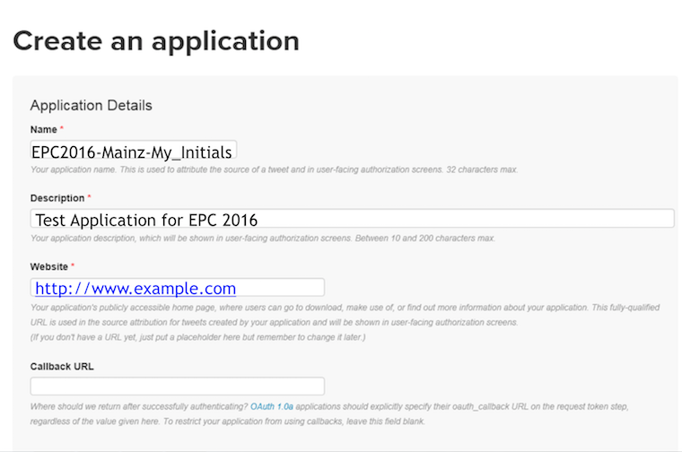

4. Obtain your consumer key, consumer secret, access token and access token secret. You will insert these credentials below
- Select Keys and Access Tokens tab
- Consumer Key and Consumer Secret are at the top of the page
- Scroll to the bottom of the page to Token actions and create Access Token and Access Token Secret

### Install R packages

You will need to have the following packages installed for the core of this workshop:

- `twitteR`
- `streamR`
- `ROAuth`
- `RCurl`
- `dplyr`

Before we can started, we need to clear our workspace, set a working directory, and load packages (you may need to install these packages the first time run this file). Fill in your working directory below by replacing “FILL ME IN” with the file path of your workshop folder. If you clone the data from the repository your file path will end with “iussp-mainz-social-media/Twitter”

```r
# set working directory
rm(list=ls())
setwd("FILL ME IN/iussp-mainz-social-media/Twitter")
#' uncomment the command below to install the necessary packages
#install.packages(c("twitteR","streamR","ROAuth", "RCurl", "dplyr", "lubridate", "stringr", "base64enc"))

library(twitteR)
library(streamR)
library(ROAuth)
library(RCurl)
library(dplyr)
library(lubridate)
library(stringr)
library(base64enc)

#' Pablo Barbera, author of streamR, has written additional functions for Twitter analysis
#' uncomment the two commands below to download and add these functions to your environment with source
#download.file("https://raw.githubusercontent.com/pablobarbera/social-media-workshop/master/functions.r", "functions_by_pablobarbera.R")
#source("functions_by_pablobarbera.R")

#' few functions to clean data
source("twitterFunctions.R")
```

### Twitter API Authentication

We will use two packages, streamR and twitteR, to retrieve tweets from the Twitter API. To access the functions in these packages, we will complete two authentication procedures.

- streamR
  - Allows authorized applications to access [Twitter’s Streaming API](https://dev.twitter.com/streaming/overview)
  - real-time collection and monitoring of tweets
  - uses stored authentication
- twitteR
  - Allows authorized applications to access [Twitter’s API](https://dev.twitter.com/rest/public)
  - read and post tweets with API responses
  - uses direct authentication

```r
#' Twitter credentials for streamR and twitteR authentication
consumer_key <- "FILL ME IN"
consumer_secret<- "FILL ME IN"
access_token<- "FILL ME IN"
access_token_secret<- "FILL ME IN"

#' parameters and URLs for streamR authentication
reqURL <- "https://api.twitter.com/oauth/request_token"
accessURL<- "https://api.twitter.com/oauth/access_token"
authURL<- "https://api.twitter.com/oauth/authorize"

#' Note:  You only need to create an authentication object for streamR once
#' Microsoft Windows users need to uncomment the following command to download a cert file
#download.file(url="http://curl.haxx.se/ca/cacert.pem", destfile="cacert.pem")

#' create an object "cred" that will save the authenticated object for later sessions
twitCred<- OAuthFactory$new(consumerKey=consumer_key,consumerSecret=consumer_secret,
                            requestURL=reqURL,accessURL=accessURL,authURL=authURL)

#' executing twitCred$handshake will redirect you to a website and provide your app a PIN
#' insert the PIN in the R console after you run this line
#' you can save authenticated credentials for later sessions
#' for later use, uncomment the following command in a folder that contains twitCred.RData
#load("twitCred.RData")
twitCred$handshake(cainfo = system.file("CurlSSL", "cacert.pem", package = "RCurl"))
save(twitCred, file = "twitCred.RData")

#' setup direct Twitter authentication for twitteR functions
#' you will be prompted to cache authentication token
#' you will need to repeat this step unless you are running analysis from a location with a
#' cached authentication token
setup_twitter_oauth(consumer_key, consumer_secret, access_token, access_token_secret)
```

Twitter authentication for streamR (Windows output with `download.file` executed shown)

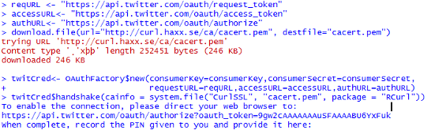

# Analysis

Save all objects in your current workspace and read back from file in the future

```r
save.image(file = "EPC2016-Mainz-Twitter.RData")

#' future R sessions will require you to reload necessary libraries
#' uncomment the command below to load saved objects in future workspace sessions
#load("EPC2016-Mainz-Twitter.RData")
```

# References

1. Create a [Twitter account](https://www.twitter.com/signup)
2. Verify Twitter account, by adding a mobile phone number [instructions](https://support.twitter.com/articles/110250)
3. Create a [new app](https://dev.twitter.com)
4. [Twitter’s Streaming API](https://dev.twitter.com/streaming/overview)
5. [Twitter’s REST API](https://dev.twitter.com/rest/public)
6. [streamR vignette](http://pablobarbera.com/code/streamR.html) by Pablo Barbera

# Acknowledgements

I would like to thank workshop collaborators (Emilio Zagheni and Monica Alexander) for their questions and feedback while creating this module.